# A06- ggplot

Nandagopal Panicker

07/24/2024

## Bicycle Sharing

Capital BikeShare is a bicycle-sharing system in Washington, D.C. At any of about 400 stations, a registered user can unlock and check out a bicycle. After use, the bike can be returned to the same station or any of the other stations.

Such sharing systems require careful management. There need to be enough bikes at each station to satisfy the demand, and enough empty docks at the destination station so that the bikes can be returned. At each station, bikes are checked out and are returned over the course of the day. An imbalance between bikes checked out and bikes returned calls for the system administration to truck bikes from one station to another. This is expensive.

In order to manage the system, and to support a smart-phone app so that users can find out when bikes are available, Capital BikeShare collects real-time data on when and where each bike is checked out or returned, how many bikes and empty docks there are at each station. Capital BikeShare publishes the station-level information in real time. The organization also publishes, at the end of each quarter of the year, the historical record of each bike rental in that time.

You can access the data from the Capital Bikeshare web site. Doing this requires some translation and cleaning, skills that are introduced in Chapter 16. For this project, however, already translated and cleaned data are provided in the form of two data tables:

- `Stations` giving information about location of each of the stations in the system.
- `Trips` is a random subset of 10,000 trips from the full quarterly data, giving the rental history over the last quarter of 2014 (Q4).

```r
library(tidyverse)

station_url <- "https://mdbeckman.github.io/dcSupplement/data/DC-Stations.csv"
Stations <- readr::read_csv(station_url)
trip_url <- "https://mdbeckman.github.io/dcSupplement/data/Trips-History-Data-2014-Q4-Small.rds"
Trips <- readRDS(gzcon(url(trip_url)))
```

In this activity, you’ll work with just a few variables:

From `Stations`:

- the latitude (`lat`) and longitude (`long`) of the bicycle rental station
- `name`: the station’s name

From Trips:

- `sstation`: the name of the station where the bicycle was checked out.
- `estation`: the name of the station to which the bicycle was returned.
- `client`: indicates whether the customer is a “regular” user who has paid a yearly membership fee, or a “casual” user who has paid a fee for five-day membership.
- `sdate`: the time and date of check-out
- `edate`: the time and date of return

(Notice that the location and time variables start with an “s” or an “e” to indicate whether the variable is about the **s**tart of a trip or the **e**nd of a trip.)

Time/dates are typically stored as a special kind of number: a **POSIX** date.

**POSIX** date: A representation of date and time of day that facilitates using dates in the same way as numbers, e.g. to find the time elapsed between two dates. You can use `sdate` and `edate` in the same way that you would use a number. For instance, the figure below shows the distribution of times that bikes were checked out.

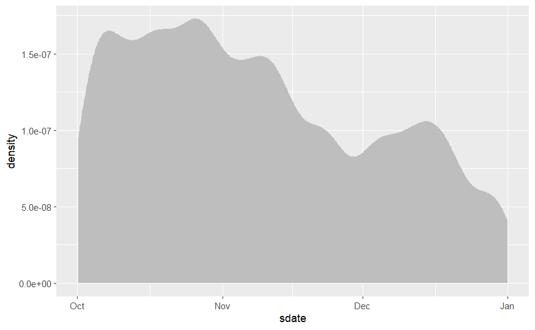

```r
Trips %>%
  ggplot(aes(x = sdate)) +
  geom_density(fill = "gray", color = NA)
```

## Question 1: How Long?

Make a box-and-whisker plot, like Figure [18.2 of the Project: Bicycle Sharing](https://dtkaplan.github.io/DataComputingEbook/project-bicycle-sharing.html#fig:box-whisker-bike) showing the distribution of the duration of rental events, broken down by the client type. The duration of the rental can be calculated as `as.numeric(edate - sdate)`. The units will be in either hours, minutes, or seconds. It should not be much trouble for you to figure out which one.

When you make your plot, you will likely find that the axis range is being set by a few outliers. These may be bikes that were forgotten. Arrange your scale to ignore these outliers, or filter them out.

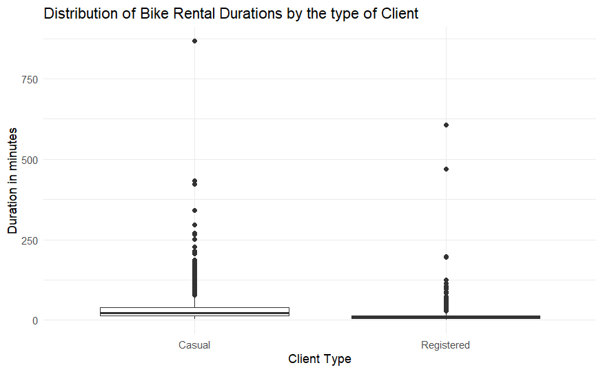

```r
Trips <- Trips %>%
  mutate(duration = as.numeric(difftime(edate, sdate, units = "mins")))
Trips_filtered <- Trips %>%
  filter(duration <= 1440)
Trips_filtered %>%
  ggplot(aes(x = client, y = duration)) +
  geom_boxplot() +
  labs(title = "Distribution of Bike Rental Durations by the type of Client",
       x = "Client Type",
       y = "Duration in minutes") +
  theme_minimal()
```

## Question 2: When are bikes used?

The `sdate` variable in Trips indicates the date and time of day that the bicycle was checked out of the parking station. `sdate` is stored as a special variable type that includes detailed information about the date and time.

Often, you will want discrete components of a date, for instance:

| Date Component | Function (`lubridate` package) |
| --- | --- |
| Day of the year (1-365) | `lubridate::yday(sdate)` |
| Day of the week (Sunday to Saturday) | `lubridate::wday(sdate)` |
| Hour of the day | `lubridate::hour(sdate)` |
| Minute in the hour | `lubridate::minute(sdate)` |

Create **histograms or density plots** for bike use over the following discrete time periods. For each plot, provide 2-3 sentences describing your observations.

1. day of the year (1 to 365)
2. day of the week (Sunday to Saturday)
3. hour of the day (0 to 24)
4. minute in the hour (0 to 60)

You can use [Figure 18.3](https://dtkaplan.github.io/DataComputingEbook/project-bicycle-sharing.html#fig:bikes-over-hours) or [Figure 18.4](https://dtkaplan.github.io/DataComputingEbook/project-bicycle-sharing.html#fig:bike-hour-count) as examples.

### Day of Year

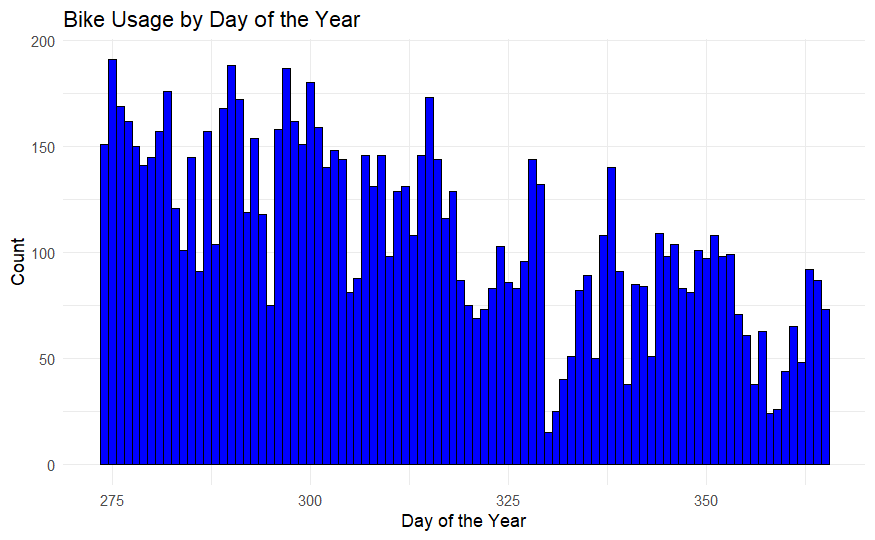

```r
Trips_dty <- Trips %>%
  mutate(day_of_year = as.numeric(format(sdate, "%j")))
Trips_dty %>%
  ggplot(aes(x = day_of_year)) +
  geom_histogram(binwidth = 1, fill = "blue", color = "black") +
  labs(title = "Bike Usage by Day of the Year",
       x = "Day of the Year",
       y = "Count") +
  theme_minimal()
```

### Day of Week

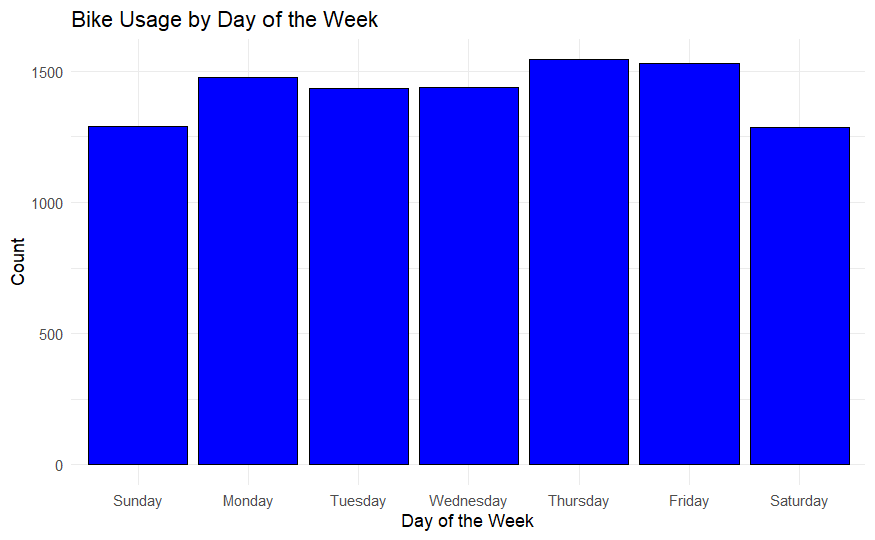

```r
Trips_dow <- Trips %>%
  mutate(day_of_week = factor(format(sdate, "%A"), levels = c("Sunday", "Monday", "Tuesday", "Wednesday", "Thursday", "Friday", "Saturday")))
Trips_dow %>%
  ggplot(aes(x = day_of_week)) +
  geom_bar(fill = "blue", color = "black") +
  labs(title = "Bike Usage by Day of the Week",
       x = "Day of the Week",
       y = "Count") +
  theme_minimal()
```

### Hour of Day

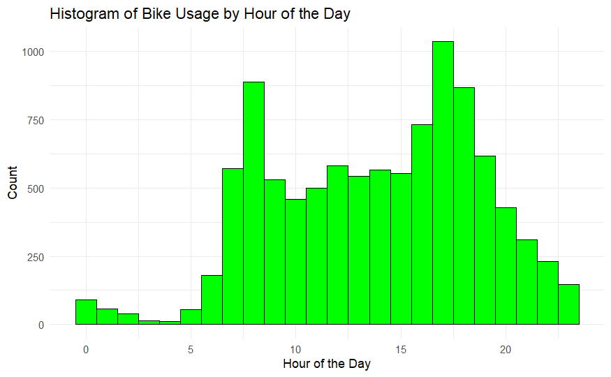

```r
Trips_hour <- Trips %>%
  mutate(hour_of_day = as.numeric(format(sdate, "%H")))

Trips_hour %>%
  ggplot(aes(x = hour_of_day)) +
  geom_histogram(binwidth = 1, fill = "green", color = "black") +
  labs(title = "Histogram of Bike Usage by Hour of the Day",
       x = "Hour of the Day",
       y = "Count") +
  theme_minimal()
```

We can see at hour 17 of the day is when the bikes are most used. They are least used at hour 4 of the day.

After the first 5-6 hours of the day, they seem to be used extensively.

### Minute of Hour

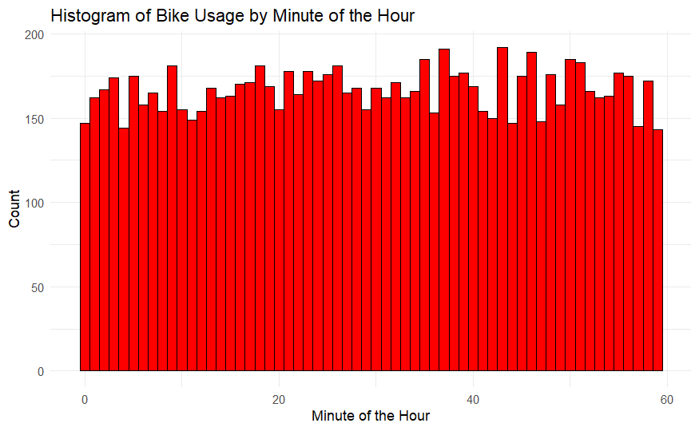

```r
Trips_minute <- Trips %>%
  mutate(minute_of_hour = as.numeric(format(sdate, "%M")))

Trips_minute %>%
  ggplot(aes(x = minute_of_hour)) +
  geom_histogram(binwidth = 1, fill = "red", color = "black") +
  labs(title = "Histogram of Bike Usage by Minute of the Hour",
       x = "Minute of the Hour",
       y = "Count") +
  theme_minimal()
```

They are used the most on the 43rd minute of the hour. They are used the least in what seems to be the 60th minute of the hour. However, they seem to be used uniformly throughout the hour.

## Question 3: Grouping

Group the bike rentals by three variables: hour of the day, day of the week, and client type. Find the total number of events in each grouping and plot this count versus hour. Use the group aesthetic to represent one of the other variables and faceting to represent the other. Comment on any general trends you see.

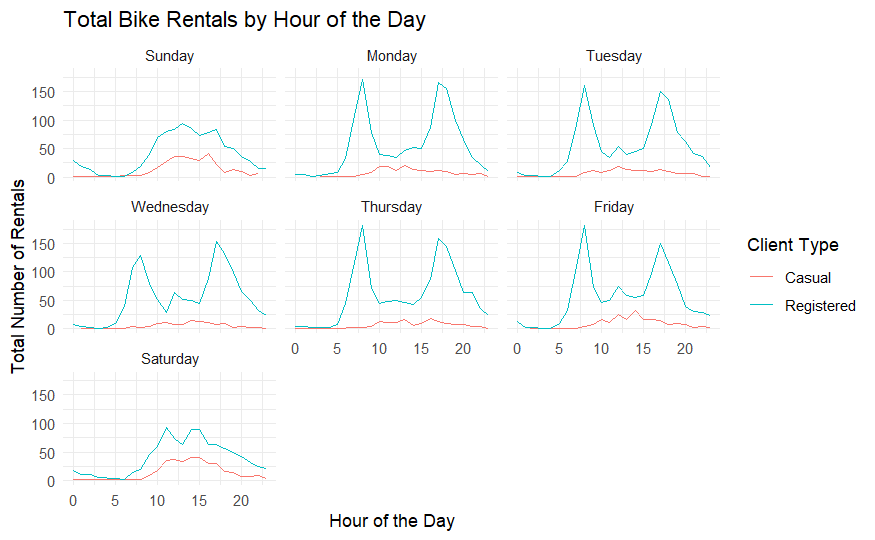

```r
Trips_grouped <- Trips %>%
  mutate(hour_of_day = as.numeric(format(sdate, "%H")),
         day_of_week = factor(format(sdate, "%A"),
                              levels = c("Sunday", "Monday", "Tuesday", "Wednesday", "Thursday", "Friday", "Saturday")))

Trips_summary <- Trips_grouped %>%
  group_by(hour_of_day, day_of_week, client) %>%
  summarise(total_events = n(), .groups = 'drop')

ggplot(Trips_summary, aes(x = hour_of_day, y = total_events, color = client)) +
  geom_line() +
  facet_wrap(~ day_of_week) +
  labs(title = "Total Bike Rentals by Hour of the Day",
       x = "Hour of the Day",
       y = "Total Number of Rentals",
       color = "Client Type") +
  theme_minimal()
```

We can see from Mondays through Fridays, the bikes are most used between hours 5-10 and hours 15-20. On Sundays and Saturdays they are most used hours 10 - 17.5.

There are a lot more registered clients using the bikes everyday than there are casual clients.